# 40-model

## Splitting the data for train and test:

`r`r set.seed(44) data_index <- createDataPartition(Clean_norm_BreastCancer$Diagnosis, p=0.7 , list=F) train <- Clean_norm_BreastCancer[data_index, 1:10] test <- Clean_norm_BreastCancer[-data_index,1:10]

# Kmeans Clustering :

Hypothesis: I want to check whether including the Mitoses_adjusted_discreet will increase or decrease the accuracy of the models.

Let’s apply the kmeans clustering algorithm to find out whether the data is clustered in benign or malignant with mitoses_adjusted_discreet.

`r`r set.seed(44) k2 <- kmeans(Clean_norm_BreastCancer[,c(2,10)], centers = 2, nstart = 25)

#Print the results

fviz_cluster(k2, data = Clean_norm_BreastCancer[,c(2,10)])

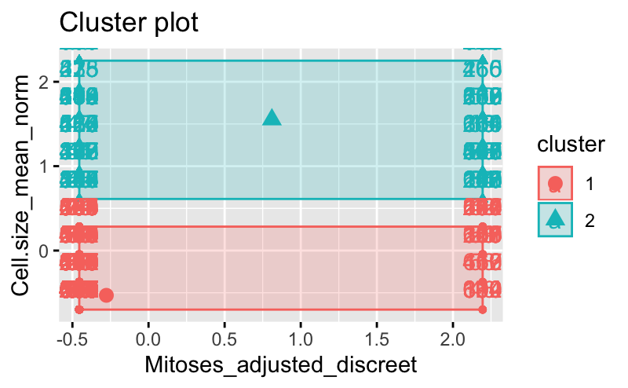

Checking the clusters:

`r`r k2$cluster

[output not shown]

Printing the Consfusion matrix to check the false positive, false negative, true positive and true negative.

`r`r table(k2$cluster,Clean_norm_BreastCancer$Diagnosis)

```
      1   2
  1 453  68
  2   5 173
```

Checking the accuracy:

`r`r Overall_Accuracy <- (453+173)/(699) print(Overall_Accuracy)

```
[1] 0.8955651
```

So, we got overall accuracy of 89.5%.

Let’s apply the kmeans clustering algorithm to find out whether the data is clustered in benign or malignant without mitoses_adjusted_discreet.

`r`r set.seed(44) k2 <- kmeans(Clean_norm_BreastCancer[,c(3,10)], centers = 2, nstart = 25)

#Print the results

fviz_cluster(k2, data = Clean_norm_BreastCancer[,c(3,10)])

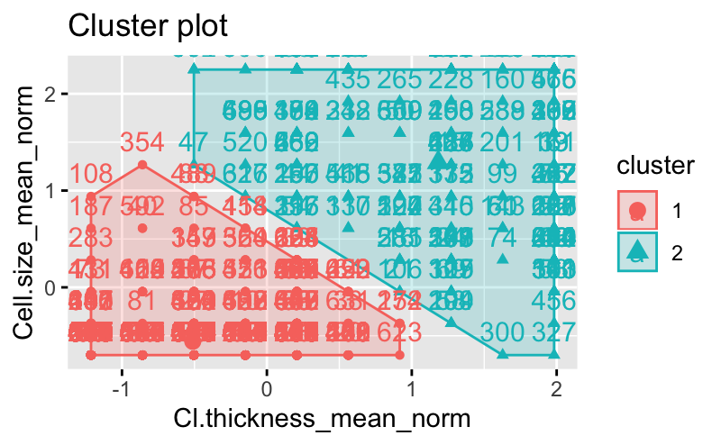

Checking the clusters:

`r`r k2$cluster

[output not shown]

Printing the Consfusion matrix to check the false positive, false negative, true positive and true negative.

`r`r table(k2$cluster,Clean_norm_BreastCancer$Diagnosis)

```
      1   2
  1 449  39
  2   9 202
```

Checking the accuracy:

`r`r Overall_Accuracy <- (449+202)/(699) print(Overall_Accuracy)

```
[1] 0.9313305
```

So, we got overall accuracy of 93.13%. So we can say that it’s better to not include the mitoses_adjusted_discreet column. It makes sense because as we have seen in the corrplot it has the least correaltion with pther columns.

Let’s apply Random Forest to compare models to check which is better optimized for this dataset.

## Random Forest :

Printing out the Confusion Matrix and Accuracy:

`r`r pred_rf <- predict(model_rf,test) cm_rf <- confusionMatrix(pred_rf,test$Diagnosis,positive = ‘2’) cm_rf

```
Confusion Matrix and Statistics

          Reference
Prediction   1   2
         1 132   2
         2   5  70

               Accuracy : 0.9665
                 95% CI : (0.9322, 0.9864)
    No Information Rate : 0.6555
    P-Value [Acc > NIR] : <2e-16

                  Kappa : 0.9266

 Mcnemar's Test P-Value : 0.4497

            Sensitivity : 0.9722
            Specificity : 0.9635
         Pos Pred Value : 0.9333
         Neg Pred Value : 0.9851
             Prevalence : 0.3445
         Detection Rate : 0.3349
   Detection Prevalence : 0.3589
      Balanced Accuracy : 0.9679

       'Positive' Class : 2
```

As we can see above that overall accuracy with Random Forest is 96.65%.